# Exploring data with R tutorial

Erin W Dickie

September 11, 2016

[Return to SCWG Home](https://camh-scwg.github.io/compucool-oct-2016/)

Please download the following files:

1. messy_demographic.csv
2. messy_cognitive.csv
3. messy_genotype.csv

Load the packages

```r
library(ggplot2)
library(dplyr)
library(tidyr)
library(broom)
library(knitr)
```

The data should be merged and ready to go from day 1. If not, here’s the code for it:

```r
data1 <- read.csv("~/Downloads/messy_demographic.csv")  # put in the location of the downloaded data file 1
data2 <- read.csv("~/Downloads/messy_cognitive.csv")  # put in the location of the downloaded data file 2
data3 <- read.csv("~/Downloads/messy_genotype.csv")
```

```r
data1[data1==""] <- NA
data1[data1=="missing"] <- NA
data1[data1=="9999"] <- NA

data1$age <- as.numeric(as.character(data1$age))
data1$ethnicity <- factor(data1$ethnicity,levels=c("Cauc","AA","As","In","Other"))
data1$sex <- factor(data1$sex, levels=c(0,1), labels=c("Male","Female"))
data1$dx <- factor(data1$dx, levels=c(0,1), labels=c("Control","Case"))

data2[data2==""] <- NA
data2[data2=="missing"] <- NA
data2[data2=="9999"] <- NA
data2$cog1 <- as.numeric(as.character(data2$cog1))
data2$cog2 <- as.numeric(as.character(data2$cog2))
data2$cog3 <- as.numeric(as.character(data2$cog3))
data2$subID <- gsub(data2$subID,pattern="subject",replacement="SUB_")

data3[data3==""] <- NA
data3[data3=="missing"] <- NA
data3[data3=="9999"] <- NA
data3$genotype <- factor(data3$genotype, levels=c(0,1,2), labels=c("AA","AG","GG"))
data3$subID <- gsub(data3$subID,pattern="subject",replacement="SUB_")

alldata <- merge(data1,data2,by.x="subject_ID",by.y="subID")
alldata <- merge(alldata,data3,by.x="subject_ID",by.y="subID")

## Write merged dataframe as new .csv
write.csv(alldata, "alldata.csv", row.names=F)
```

## RESEARCH QUESTION 3:

#### cog1 ~ dx (t-test)

```r
t.test(data=alldata, cog1 ~ dx)
```

```
##
##  Welch Two Sample t-test
##
## data:  cog1 by dx
## t = -6.347, df = 334.916, p-value = 7.133e-10
## alternative hypothesis: true difference in means is not equal to 0
## 95 percent confidence interval:
##  -2.871388 -1.512676
## sample estimates:
## mean in group Control    mean in group Case
##              9.940047             12.132079
```

Wow we have a result!! But one of my favorite things output R is that the statistical output can be saved as an object!!

```r
my.t.result <- t.test(data=alldata, cog1 ~ dx) # saves to output to my.t.result

print(my.t.result)       ## prints to output to the console
```

```
##
##  Welch Two Sample t-test
##
## data:  cog1 by dx
## t = -6.347, df = 334.916, p-value = 7.133e-10
## alternative hypothesis: true difference in means is not equal to 0
## 95 percent confidence interval:
##  -2.871388 -1.512676
## sample estimates:
## mean in group Control    mean in group Case
##              9.940047             12.132079
```

```r
my.t.result$statistic    ## gets us the t statistic!
```

```
##         t
## -6.347017
```

```r
my.t.result$parameter    ## the degrees of freedom
```

```
##       df
## 334.9162
```

```r
my.t.result$p.value      ## gets us the p-value
```

```
## [1] 7.13299e-10
```

```r
round(my.t.result$statistic,2) ## we can these numbers using the "round" function
```

```
##     t
## -6.35
```

Let’s put these three together into something we might want to report in our paper

```r
my.t.results.txt = paste0('t(',
                        round(my.t.result$parameter,1),
                        ') = ',
                        round(my.t.result$statistic,2), ', p = ',
                        round(my.t.result$p.value, 7))

my.t.results.txt
```

```
## [1] "t(334.9) = -6.35, p = 0"
```

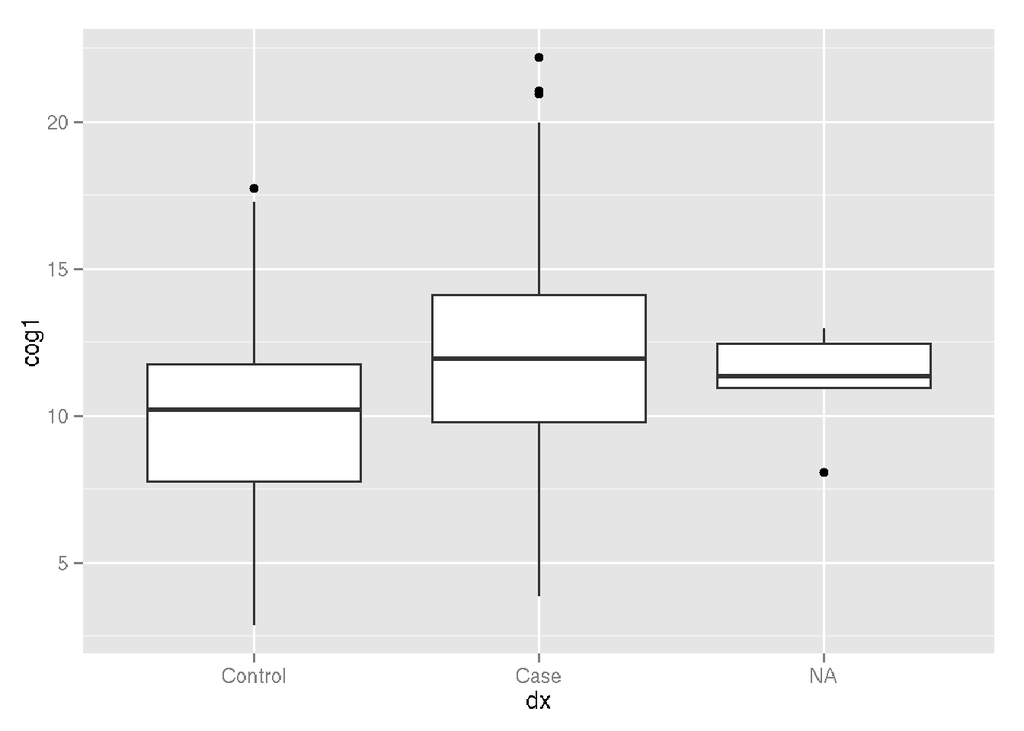

```r
ggplot(data=alldata, aes(y=cog1,x=dx)) +
    geom_boxplot()
```

#### Let’s make it fancier:

First - let’s deal with the NA’s we don’t want to plot - let’s remove them from the plotting dataset

[figure not shown]

```r
data.toplot <-filter(alldata, !is.na(cog1), !is.na(dx))

ggplot(data.toplot, aes(y=cog1,x=dx)) +
    geom_boxplot(outlier.shape=NA) + ## removes outliers from boxplot layer
    geom_jitter(alpha=0.5)           ## add dots on top
```

[figure not shown]

```r
## even fancier - let's add a title, and annotation and label the axes
ggplot(data.toplot, aes(y=cog1,x=dx)) +
  geom_boxplot(outlier.shape=NA) +
  geom_jitter(alpha=0.5) +
  labs(title="Effect of Diagnosis on Cog Score #1",
       y = "Cognitive Test 1",
       x = "Diagnosis") +
  annotate("text", label = my.t.results.txt, x = 1, y = 21) +
  theme_bw()
```

#### NOW LET’s save our plot!!!

**Note**: we can start by using the “Export” button in the plots tab..

```r
ggsave('figure1_ttestresults.pdf', width = 5, height = 5)
```

## Let’s make a diagnosis by cognition table

```r
my.stats.table <- summarise(alldata,
                            "Mean" = mean(cog1, na.rm = T),
                            "St Dev" = sd(cog1, na.rm = T))

my.stats.table <- alldata %>%
                  group_by(dx,sex) %>%
                  summarise("Mean" = mean(cog1, na.rm = T),
                            "St Dev" = sd(cog1, na.rm = T))

kable(my.stats.table)
```

| dx | sex | Mean | St Dev |
| --- | --- | --- | --- |
| Control | Male | 10.476754 | 2.7469625 |
| Control | Female | 9.746893 | 2.9514609 |
| Control | NA | 12.254830 | 1.5465560 |
| Case | Male | 12.215568 | 3.5483599 |
| Case | Female | 12.022392 | 3.3859637 |
| Case | NA | 13.036707 | 0.1736939 |
| NA | Male | 11.868654 | 1.0237882 |
| NA | Female | 10.580708 | 2.3376551 |

## reshaping data to look at all three cognitive scores

### but let’s look at all three subscales….

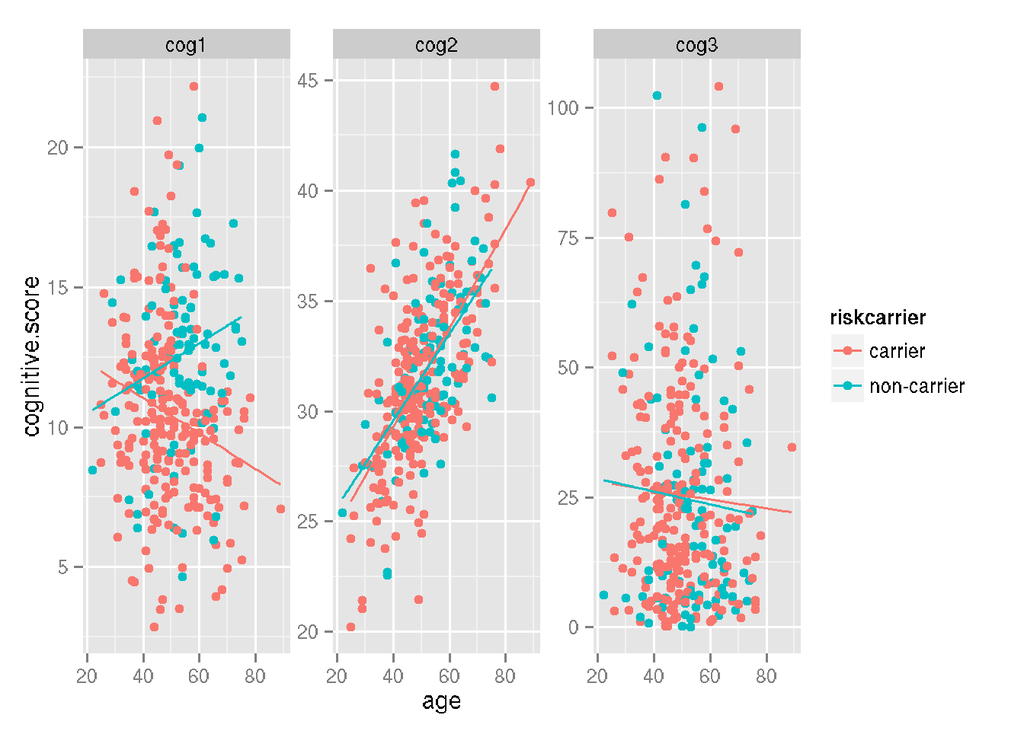

```r
## let's add a rick carrier
alldata$riskcarrier[alldata$genotype=="AG" | alldata$genotype=="GG"] <- "carrier"
alldata$riskcarrier[alldata$genotype=="AA"] <- "non-carrier"
alldata$riskcarrier <- as.factor(alldata$riskcarrier)

alldata_melted <- gather(alldata, cog_var, cognitive.score,
                  -subject_ID, -age, -sex, -ethnicity, -dx, -genotype, -riskcarrier)

toplot <- filter(alldata_melted, !is.na(cognitive.score),
                                 !is.na(dx),
                                 !is.na(riskcarrier))

ggplot(toplot, aes(y=cognitive.score,x=age,color=riskcarrier)) +
  geom_point() +
  geom_smooth(method=lm) +
  facet_wrap(~cog_var, scales = "free")
```